# 1 Preparación de datos

```python
from time import time
from datetime import datetime, timedelta
import pandas as pd
import numpy as np
from matplotlib import*
from matplotlib.cm import register_cmap
import matplotlib.pyplot as plt
from sklearn.impute import SimpleImputer
from sklearn.preprocessing import OneHotEncoder, StandardScaler, OrdinalEncoder, MinMaxScaler
from sklearn.compose import make_column_transformer, ColumnTransformer
from sklearn.pipeline import Pipeline
from sklearn.neighbors import KNeighborsRegressor
from sklearn.model_selection import train_test_split
from sklearn import metrics
from sklearn.metrics import accuracy_score, precision_score, recall_score, f1_score, confusion_matrix
from sklearn.datasets import load_iris
from sklearn.model_selection import train_test_split
from sklearn.naive_bayes import GaussianNB
import pickle
import seaborn as sns
import copy

#from sklearn.neighbors import KNeighborsRegressor
#from sklearn.model_selection import train_test_split
#from sklearn.model_selection import cross_val_score
#from sklearn.model_selection import GridSearchCV

#from sklearn.model_selection import cross_val_score
#from sklearn.model_selection import StratifiedKFold
#from sklearn.model_selection import ShuffleSplit
#from sklearn.model_selection import KFold
#from sklearn.model_selection import GridSearchCV
#from keras.layers import Dropout

#from sklearn import metrics
#from sklearn.metrics import confusion_matrix
#from sklearn.metrics import accuracy_score
#from sklearn.metrics import precision_score
#from sklearn.metrics import recall_score
#from sklearn.metrics import f1_score

from scipy import stats
from sklearn.decomposition import PCA as sklearnPCA
import seaborn
from sklearn import set_config
print('Módulos importados')
```

```
Módulos importados
```

```python
# Funciones para guardar y cargar un Pipeline o Modelo
def guardarPipeline(pipeline,nombreArchivo):
    with open(nombreArchivo+'.pickle', 'wb') as handle:
        pickle.dump(pipeline, handle, protocol=pickle.HIGHEST_PROTOCOL)

def transformarVariables(dataframe, categorical_ordinal_features, categorical_nominal_features, numeric_features, salida):
    dataframeTransformado=copy.deepcopy(dataframe)
    cantidadTotalVariables = len(dataframeTransformado.columns)
    print('Cantidad de variables antes de transformación de variables: ',cantidadTotalVariables)
    cantidadVariablesNominales = len(categorical_nominal_features)
    cantidadVariablesBinarias=0
    for variable in categorical_nominal_features:
        cantidadVariablesBinarias=cantidadVariablesBinarias+dataframeTransformado[variable].nunique()
    print('Cantidad de variables binarias: ',cantidadVariablesBinarias)
    cantidadTotalVariablesConTransformacion = cantidadTotalVariables - cantidadVariablesNominales + cantidadVariablesBinarias
    print('Cantidad de variables que habrá después de transformación de variables: ',cantidadTotalVariablesConTransformacion)
    #Definición de transformadores (preprocesadores)
    #1. Preprocesador de variables categóricas a numéricas (ordinales y nominales)
    categorical_ordinal_transformer = Pipeline(steps=[
        ('ordinal', OrdinalEncoder())])
    categorical_nominal_transformer_ConNombres = Pipeline(steps=[
        ('onehot', OneHotEncoder(sparse = False, handle_unknown = "ignore"))])# se ignorará una categoría desconocida
    preprocesorCategoricoNumericoConNombres = ColumnTransformer(
        transformers=[
            ('catord', categorical_ordinal_transformer, categorical_ordinal_features),
            ('catnom', categorical_nominal_transformer_ConNombres, categorical_nominal_features)
        ],remainder='passthrough',n_jobs=-1)
    #2. Normalización y Scaling: Preprocesador de variables numéricas con transformación MinMaxScaler
    minmax_transformer = Pipeline(steps=[
        ('minmax', MinMaxScaler(feature_range=(0, 1)))])
    preprocesorMinMax = ColumnTransformer(transformers =[
        ('tranminmax', minmax_transformer, list(range(cantidadTotalVariablesConTransformacion)))
    ], remainder ='passthrough')
    #3. Estandarización: Preprocesador de variables numéricas con transformación StandardScaler
    standardscaler_transformer = Pipeline(steps=[
        ('scaler', StandardScaler(with_mean=True,with_std=True))])
    preprocesorStandardScaler = ColumnTransformer(transformers =[
        ('transcaler', standardscaler_transformer, list(range(cantidadTotalVariablesConTransformacion)))
    ], remainder ='passthrough')
    #Construcción de Pipeline con transformadores
    pipe = Pipeline(steps=[
        ('prepcn', preprocesorCategoricoNumericoConNombres),
        #('prepstandard', preprocesorStandardScaler)
        ('prepminmax', preprocesorMinMax)
    ])
    #Transformación de variables
    X_Transformado = pipe.fit_transform(dataframeTransformado)
    print('********** Pipeline aplicado')
    guardarPipeline(pipe,'pipePreprocesadores')
    set_config(display='diagram')
    #Formación de dataframe transformado
    cnamesDataset1=[]
    if len(categorical_ordinal_features)!=0:
        cnamesDataset1.extend(categorical_ordinal_features)
    if len(categorical_nominal_features)!=0:
        cnamesDataset2 = pipe.named_steps['prepcn'].transformers_[1][1].named_steps['onehot'].get_feature_names_out(categorical_nominal_features)
        cnamesDataset1.extend(cnamesDataset2)
    cnamesDataset3 = numeric_features
    cnamesDataset1.extend(cnamesDataset3)
    #print(cnamesDataset1)
    dataframeTransformado = pd.DataFrame(data=X_Transformado,columns=cnamesDataset1)
    dataframeTransformado = pd.concat([dataframeTransformado, salida], axis = 1)
    return dataframeTransformado, pipe

def guardarModelo(pipeline,nombreArchivo):
    with open(nombreArchivo+'.pickle', 'wb') as handle:
        pickle.dump(pipeline, handle, protocol=pickle.HIGHEST_PROTOCOL)
        print("********** Pickle guardado")

def transformarPrediccion(lista):
    for i in range(len(lista)):
        desempenio=lista[i]
        #print(desempenio)
        if (desempenio < 0):
            desempenio = 0
        elif (desempenio > 1):
            desempenio = 1
        lista[i]=desempenio
    return lista

print("Funciones definidas")
```

```
Funciones definidas
```

1. Preprocesamiento de datos: a partir del dataset Hepatitis que tiene variables categóricas y numéricas: https://archive.ics.uci.edu/ml/datasets/Hepatitis Otros datasets públicos se encuentran en:
- https://archive.ics.uci.edu/ml/index.php
- https://www.kaggle.com/datasets

### **b. Describir en la siguiente tabla cada variable, indicar el tipo de variable y técnica o técnicas a utilizar para transformar la variable. Basarse en el ejemplo de la siguiente tabla:**

[figure not shown]

```python
nombresVariables=['CLASE','EDAD','SEXO','ESTEROIDES','ANTIVIRALES','FATIGA',
                  'MALESTAR','ANOREXIA','HIGADOGRANDE','HIGADOFIRME','BAZOPALPABLE','ARAÑAS',
                  'ASCITIS','VARICES','BILIRRUBINA','FOSFATASAALCALINA','SGOT','ALBUMINA',
                  'PRUEBADETIEMPO','HISTOLOGIA']
#df = pd.read_csv('C:\Users\USER\Downloads\hepatitis.csv')
#df = pd.read_csv('C:\Users\USER\Downloads\hepatitis.csv', delimiter=';')
dfOriginal = pd.read_csv("hepatitis.csv", sep = ",", names = nombresVariables)
dfOriginal = dfOriginal.replace('?', 1)
dfOriginal.head()
```

|  | CLASE | EDAD | SEXO | ESTEROIDES | ANTIVIRALES | FATIGA | MALESTAR | ANOREXIA | HIGADOGRANDE | HIGADOFIRME | BAZOPALPABLE | ARAÑAS | ASCITIS | VARICES | BILIRRUBINA | FOSFATASAALCALINA | SGOT | ALBUMINA | PRUEBADETIEMPO | HISTOLOGIA |
| --- | --- | --- | --- | --- | --- | --- | --- | --- | --- | --- | --- | --- | --- | --- | --- | --- | --- | --- | --- | --- |
| 0 | 2 | 30 | 2 | 1 | 2 | 2 | 2 | 2 | 1 | 2 | 2 | 2 | 2 | 2 | 1.00 | 85 | 18 | 4.0 | 1 | 1 |
| 1 | 2 | 50 | 1 | 1 | 2 | 1 | 2 | 2 | 1 | 2 | 2 | 2 | 2 | 2 | 0.90 | 135 | 42 | 3.5 | 1 | 1 |
| 2 | 2 | 78 | 1 | 2 | 2 | 1 | 2 | 2 | 2 | 2 | 2 | 2 | 2 | 2 | 0.70 | 96 | 32 | 4.0 | 1 | 1 |
| 3 | 2 | 31 | 1 | 1 | 1 | 2 | 2 | 2 | 2 | 2 | 2 | 2 | 2 | 2 | 0.70 | 46 | 52 | 4.0 | 80 | 1 |
| 4 | 2 | 34 | 1 | 2 | 2 | 2 | 2 | 2 | 2 | 2 | 2 | 2 | 2 | 2 | 1.00 | 1 | 200 | 4.0 | 1 | 1 |

```python
dataframe=copy.deepcopy(dfOriginal)
print(dataframe.shape)
Y=dataframe['CLASE']
print(dataframe.shape)
dataframe.head()
dataframe = dataframe.drop(columns=['BILIRRUBINA','ALBUMINA','CLASE'])
dataframe = dataframe.astype(int)
dataframe.head()
```

```
(155, 20)
(155, 20)
```

|  | EDAD | SEXO | ESTEROIDES | ANTIVIRALES | FATIGA | MALESTAR | ANOREXIA | HIGADOGRANDE | HIGADOFIRME | BAZOPALPABLE | ARAÑAS | ASCITIS | VARICES | FOSFATASAALCALINA | SGOT | PRUEBADETIEMPO | HISTOLOGIA |
| --- | --- | --- | --- | --- | --- | --- | --- | --- | --- | --- | --- | --- | --- | --- | --- | --- | --- |
| 0 | 30 | 2 | 1 | 2 | 2 | 2 | 2 | 1 | 2 | 2 | 2 | 2 | 2 | 85 | 18 | 1 | 1 |
| 1 | 50 | 1 | 1 | 2 | 1 | 2 | 2 | 1 | 2 | 2 | 2 | 2 | 2 | 135 | 42 | 1 | 1 |
| 2 | 78 | 1 | 2 | 2 | 1 | 2 | 2 | 2 | 2 | 2 | 2 | 2 | 2 | 96 | 32 | 1 | 1 |
| 3 | 31 | 1 | 1 | 1 | 2 | 2 | 2 | 2 | 2 | 2 | 2 | 2 | 2 | 46 | 52 | 80 | 1 |
| 4 | 34 | 1 | 2 | 2 | 2 | 2 | 2 | 2 | 2 | 2 | 2 | 2 | 2 | 1 | 200 | 1 | 1 |

```python
#Determinación de tipos de variables
categorical_ordinal_features = []
categorical_nominal_features = ['SEXO','ESTEROIDES','ANTIVIRALES','FATIGA',
                  'MALESTAR','ANOREXIA','HIGADOGRANDE','HIGADOFIRME','BAZOPALPABLE','ARAÑAS',
                  'ASCITIS','VARICES','HISTOLOGIA']
numeric_features = ['EDAD','FOSFATASAALCALINA','SGOT',
                  'PRUEBADETIEMPO']
salida=Y

dataframeTransformado, pipe=transformarVariables(dataframe, categorical_ordinal_features, categorical_nominal_features, numeric_features, salida)
dataframeTransformado.to_csv("1.DatasetTransformado.csv", sep=";",index = False)
dataframeTransformado.head()
```

[output not shown]

```python
pipe
```

```
Pipeline(steps=[('prepcn',
                 ColumnTransformer(n_jobs=-1, remainder='passthrough',
                                   transformers=[('catord',
                                                  Pipeline(steps=[('ordinal',
                                                                   OrdinalEncoder())]),
                                                  []),
                                                 ('catnom',
                                                  Pipeline(steps=[('onehot',
                                                                   OneHotEncoder(handle_unknown='ignore',
                                                                                 sparse=False))]),
                                                  ['SEXO', 'ESTEROIDES',
                                                   'ANTIVIRALES', 'FATIGA',
                                                   'MALESTAR', 'ANOREXIA',
                                                   'HIGADOGRANDE',
                                                   'HIGADOFIRME',
                                                   'BAZOPALPABLE', 'ARAÑAS',
                                                   'ASCITIS', 'VARICES',
                                                   'HISTOLOGIA'])])),
                ('prepminmax',
                 ColumnTransformer(remainder='passthrough',
                                   transformers=[('tranminmax',
                                                  Pipeline(steps=[('minmax',
                                                                   MinMaxScaler())]),
                                                  [0, 1, 2, 3, 4, 5, 6, 7, 8, 9,
                                                   10, 11, 12, 13, 14, 15, 16,
                                                   17, 18, 19, 20, 21, 22, 23,
                                                   24, 25, 26, 27, 28,
                                                   29])]))])
```

```python
dataframeTransformado.describe()
```

|  | SEXO_1 | SEXO_2 | ESTEROIDES_1 | ESTEROIDES_2 | ANTIVIRALES_1 | ANTIVIRALES_2 | FATIGA_1 | FATIGA_2 | MALESTAR_1 | MALESTAR_2 | ... | ASCITIS_2 | VARICES_1 | VARICES_2 | HISTOLOGIA_1 | HISTOLOGIA_2 | EDAD | FOSFATASAALCALINA | SGOT | PRUEBADETIEMPO | CLASE |
| --- | --- | --- | --- | --- | --- | --- | --- | --- | --- | --- | --- | --- | --- | --- | --- | --- | --- | --- | --- | --- | --- |
| count | 155.000000 | 155.000000 | 155.000000 | 155.000000 | 155.000000 | 155.000000 | 155.000000 | 155.000000 | 155.000000 | 155.000000 | ... | 155.000000 | 155.000000 | 155.000000 | 155.000000 | 155.000000 | 155.000000 | 155.000000 | 155.000000 | 155.000000 | 155.000000 |
| mean | 0.896774 | 0.103226 | 0.496774 | 0.503226 | 0.154839 | 0.845161 | 0.651613 | 0.348387 | 0.400000 | 0.600000 | ... | 0.838710 | 0.148387 | 0.851613 | 0.548387 | 0.451613 | 0.481690 | 0.288457 | 0.127826 | 0.355484 | 1.793548 |
| std | 0.305240 | 0.305240 | 0.501610 | 0.501610 | 0.362923 | 0.362923 | 0.478004 | 0.478004 | 0.491486 | 0.491486 | ... | 0.368991 | 0.356636 | 0.356636 | 0.499266 | 0.499266 | 0.176984 | 0.210213 | 0.138336 | 0.347890 | 0.406070 |
| min | 0.000000 | 0.000000 | 0.000000 | 0.000000 | 0.000000 | 0.000000 | 0.000000 | 0.000000 | 0.000000 | 0.000000 | ... | 0.000000 | 0.000000 | 0.000000 | 0.000000 | 0.000000 | 0.000000 | 0.000000 | 0.000000 | 0.000000 | 1.000000 |
| 25% | 1.000000 | 0.000000 | 0.000000 | 0.000000 | 0.000000 | 1.000000 | 0.000000 | 0.000000 | 0.000000 | 0.000000 | ... | 1.000000 | 0.000000 | 1.000000 | 0.000000 | 0.000000 | 0.352113 | 0.170068 | 0.045595 | 0.010000 | 2.000000 |
| 50% | 1.000000 | 0.000000 | 0.000000 | 1.000000 | 0.000000 | 1.000000 | 1.000000 | 0.000000 | 0.000000 | 1.000000 | ... | 1.000000 | 0.000000 | 1.000000 | 1.000000 | 0.000000 | 0.450704 | 0.282313 | 0.083462 | 0.350000 | 2.000000 |
| 75% | 1.000000 | 0.000000 | 1.000000 | 1.000000 | 0.000000 | 1.000000 | 1.000000 | 1.000000 | 1.000000 | 1.000000 | ... | 1.000000 | 0.000000 | 1.000000 | 1.000000 | 1.000000 | 0.605634 | 0.403061 | 0.151468 | 0.650000 | 2.000000 |
| max | 1.000000 | 1.000000 | 1.000000 | 1.000000 | 1.000000 | 1.000000 | 1.000000 | 1.000000 | 1.000000 | 1.000000 | ... | 1.000000 | 1.000000 | 1.000000 | 1.000000 | 1.000000 | 1.000000 | 1.000000 | 1.000000 | 1.000000 | 2.000000 |

8 rows × 31 columns

```python
dfCorrel=dataframeTransformado.corr()
dfCorrel.head()
```

|  | SEXO_1 | SEXO_2 | ESTEROIDES_1 | ESTEROIDES_2 | ANTIVIRALES_1 | ANTIVIRALES_2 | FATIGA_1 | FATIGA_2 | MALESTAR_1 | MALESTAR_2 | ... | ASCITIS_2 | VARICES_1 | VARICES_2 | HISTOLOGIA_1 | HISTOLOGIA_2 | EDAD | FOSFATASAALCALINA | SGOT | PRUEBADETIEMPO | CLASE |
| --- | --- | --- | --- | --- | --- | --- | --- | --- | --- | --- | --- | --- | --- | --- | --- | --- | --- | --- | --- | --- | --- |
| SEXO_1 | 1.000000 | -1.000000 | -0.044599 | 0.044599 | -0.089249 | 0.089249 | -0.070059 | 0.070059 | -0.025970 | 0.025970 | ... | -0.091129 | 0.022321 | -0.022321 | -0.137450 | 0.137450 | -0.008126 | -0.162503 | 0.009092 | -0.066792 | -0.173051 |
| SEXO_2 | -1.000000 | 1.000000 | 0.044599 | -0.044599 | 0.089249 | -0.089249 | 0.070059 | -0.070059 | 0.025970 | -0.025970 | ... | 0.091129 | -0.022321 | 0.022321 | 0.137450 | -0.137450 | 0.008126 | 0.162503 | -0.009092 | 0.066792 | 0.173051 |
| ESTEROIDES_1 | -0.044599 | 0.044599 | 1.000000 | -1.000000 | 0.074101 | -0.074101 | 0.157775 | -0.157775 | 0.242320 | -0.242320 | ... | 0.014712 | -0.051755 | 0.051755 | -0.083641 | 0.083641 | 0.079943 | 0.051507 | 0.026302 | -0.050691 | -0.130809 |
| ESTEROIDES_2 | 0.044599 | -0.044599 | -1.000000 | 1.000000 | -0.074101 | 0.074101 | -0.157775 | 0.157775 | -0.242320 | 0.242320 | ... | -0.014712 | 0.051755 | -0.051755 | 0.083641 | -0.083641 | -0.079943 | -0.051507 | -0.026302 | 0.050691 | 0.130809 |
| ANTIVIRALES_1 | -0.089249 | 0.089249 | 0.074101 | -0.074101 | 1.000000 | -1.000000 | -0.061339 | 0.061339 | -0.021843 | 0.021843 | ... | 0.187702 | -0.178668 | 0.178668 | 0.209242 | -0.209242 | 0.013100 | -0.042950 | -0.096130 | 0.275585 | 0.130196 |

5 rows × 31 columns

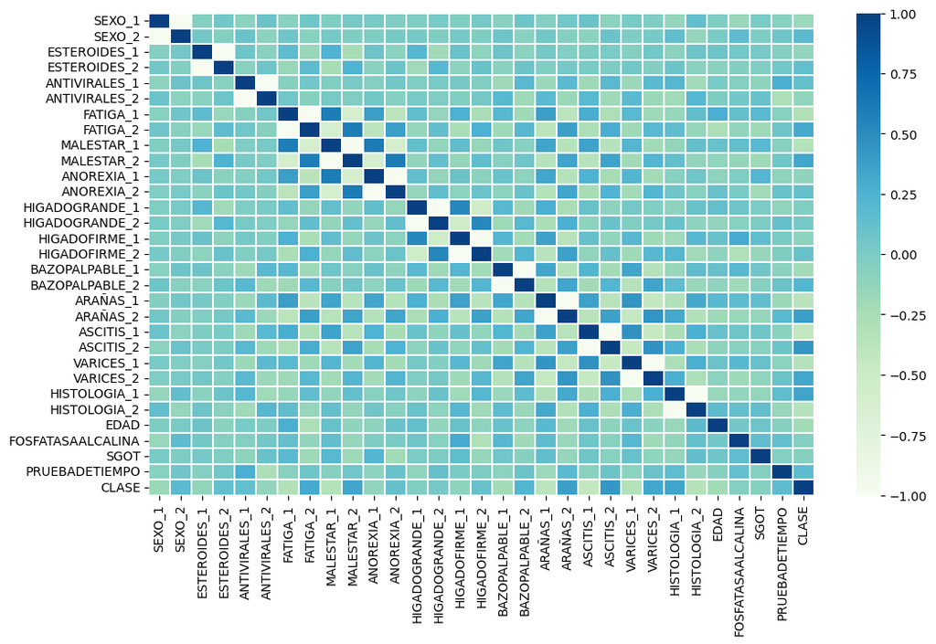

```python
fig, ax = plt.subplots(figsize = (12, 7))
#sns.heatmap(dfCorrel, cmap ='viridis', linewidths = 0.30, annot = True)
sns.heatmap(dfCorrel, cmap ='GnBu', linewidths = 0.30, annot = False)
```

```python
dfCorrOrdenado=dfCorrel.sort_values(by=['CLASE'], ascending=False)
dfCorrOrdenado['CLASE'].head(10)
```

```
CLASE             1.000000
ASCITIS_2         0.426384
ARAÑAS_2          0.379551
HISTOLOGIA_1      0.337856
MALESTAR_2        0.331869
VARICES_2         0.325153
FATIGA_2          0.306049
BAZOPALPABLE_2    0.220126
SEXO_2            0.173051
PRUEBADETIEMPO    0.156536
Name: CLASE, dtype: float64
```

```python
dfCorrOrdenado=dfCorrel.sort_values(by=['CLASE'], ascending=True)
dfCorrOrdenado['CLASE'].head(10)
```

```
ASCITIS_1        -0.426384
ARAÑAS_1         -0.379551
HISTOLOGIA_2     -0.337856
MALESTAR_1       -0.331869
VARICES_1        -0.325153
FATIGA_1         -0.306049
BAZOPALPABLE_1   -0.220126
EDAD             -0.219647
SEXO_1           -0.173051
ESTEROIDES_1     -0.130809
Name: CLASE, dtype: float64
```

## Fase 2: Aprendizaje con el Algoritmo KNN

```python
dataframeTransformado=pd.read_csv("1.DatasetTransformado.csv", sep=";")
dataframeTransformado['CLASE'] = dataframeTransformado['CLASE'].replace(2, 0)
print(dataframeTransformado.shape)
dataframeTransformado.head()
```

```
(155, 31)
```

|  | SEXO_1 | SEXO_2 | ESTEROIDES_1 | ESTEROIDES_2 | ANTIVIRALES_1 | ANTIVIRALES_2 | FATIGA_1 | FATIGA_2 | MALESTAR_1 | MALESTAR_2 | ... | ASCITIS_2 | VARICES_1 | VARICES_2 | HISTOLOGIA_1 | HISTOLOGIA_2 | EDAD | FOSFATASAALCALINA | SGOT | PRUEBADETIEMPO | CLASE |
| --- | --- | --- | --- | --- | --- | --- | --- | --- | --- | --- | --- | --- | --- | --- | --- | --- | --- | --- | --- | --- | --- |
| 0 | 0.0 | 1.0 | 1.0 | 0.0 | 0.0 | 1.0 | 0.0 | 1.0 | 0.0 | 1.0 | ... | 1.0 | 0.0 | 1.0 | 1.0 | 0.0 | 0.323944 | 0.285714 | 0.026275 | 0.01 | 0 |
| 1 | 1.0 | 0.0 | 1.0 | 0.0 | 0.0 | 1.0 | 1.0 | 0.0 | 0.0 | 1.0 | ... | 1.0 | 0.0 | 1.0 | 1.0 | 0.0 | 0.605634 | 0.455782 | 0.063369 | 0.01 | 0 |
| 2 | 1.0 | 0.0 | 0.0 | 1.0 | 0.0 | 1.0 | 1.0 | 0.0 | 0.0 | 1.0 | ... | 1.0 | 0.0 | 1.0 | 1.0 | 0.0 | 1.000000 | 0.323129 | 0.047913 | 0.01 | 0 |
| 3 | 1.0 | 0.0 | 1.0 | 0.0 | 1.0 | 0.0 | 0.0 | 1.0 | 0.0 | 1.0 | ... | 1.0 | 0.0 | 1.0 | 1.0 | 0.0 | 0.338028 | 0.153061 | 0.078825 | 0.80 | 0 |
| 4 | 1.0 | 0.0 | 0.0 | 1.0 | 0.0 | 1.0 | 0.0 | 1.0 | 0.0 | 1.0 | ... | 1.0 | 0.0 | 1.0 | 1.0 | 0.0 | 0.380282 | 0.000000 | 0.307573 | 0.01 | 0 |

5 rows × 31 columns

```python
Y = dataframeTransformado['CLASE']
dataframeTransformado=dataframeTransformado.drop(['CLASE'], axis=1)
X_Transformado=dataframeTransformado.values
X_Transformado
```

```
array([[0.        , 1.        , 1.        , ..., 0.28571429, 0.02627512,
        0.01      ],
       [1.        , 0.        , 1.        , ..., 0.45578231, 0.0633694 ,
        0.01      ],
       [1.        , 0.        , 0.        , ..., 0.32312925, 0.04791345,
        0.01      ],
       ...,
       [1.        , 0.        , 1.        , ..., 0.25170068, 0.02936631,
        0.01      ],
       [0.        , 1.        , 1.        , ..., 0.27210884, 0.02782071,
        0.48      ],
       [1.        , 0.        , 0.        , ..., 0.33673469, 0.02782071,
        0.42      ]])
```

```python
#Construcción de modelo KNN
model=KNeighborsRegressor(n_neighbors=55, metric='manhattan')#euclidean,manhattan,minkowski,chebyshev
#X_train, X_test, y_train, y_test = train_test_split(X, Y, test_size = 0.1, random_state = 42)
X_train, X_test, y_train, y_test = train_test_split(X_Transformado, Y, test_size = 0.2)
print(X_train.shape,y_train.shape)
print(X_test.shape,y_test.shape)
history = model.fit(X_train, y_train)
print('Modelo Optimizado entrenado')
guardarModelo(model,'modeloOptimizadoKNN')
print('Modelo Optimizado Guardado')
```

```
(124, 30) (124,)
(31, 30) (31,)
Modelo Optimizado entrenado
********** Pickle guardado
Modelo Optimizado Guardado
```

```python
#Predicciones
y_pred = model.predict(X_test)
y_pred = y_pred.flatten()
y_pred = transformarPrediccion(y_pred)
dataframeFinal=pd.DataFrame({'real':y_test, 'predicción': y_pred})
np.set_printoptions(formatter={'float': lambda X: "{0:0.0f}".format(X)})
dataframeFinal.head(10)
```

|  | real | predicción |
| --- | --- | --- |
| 44 | 0 | 0.036364 |
| 154 | 1 | 0.272727 |
| 86 | 1 | 0.236364 |
| 149 | 0 | 0.036364 |
| 126 | 0 | 0.381818 |
| 78 | 0 | 0.145455 |
| 34 | 0 | 0.018182 |
| 0 | 0 | 0.036364 |
| 11 | 0 | 0.072727 |
| 106 | 1 | 0.327273 |

```
Mean Absolute Error (MAE): 0.2933
Mean Squared Error (MSE): 0.1708
Root Mean Squared Error (RMSE): 0.4133
Accuracy: 0.7419354838709677
Precision:  0.0
Recall:  0.0
F1: 0.0
Matriz de confusión:
Verdaderos negativos:  23  Falsos positivos:  0  Falsos negativos:  8  Verdaderos positivos:  0
```

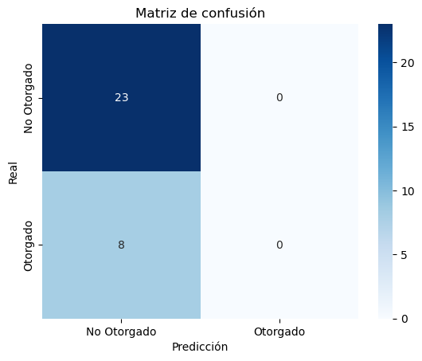

```python
MAE=metrics.mean_absolute_error(y_test, y_pred)
MSE=metrics.mean_squared_error(y_test, y_pred)
RMSE=np.sqrt(metrics.mean_squared_error(y_test, y_pred))

MAE=str(round(MAE, 4))
MSE=str(round(MSE, 4))
RMSE=str(round(RMSE, 4))

print('Mean Absolute Error (MAE):', MAE)
print('Mean Squared Error (MSE):', MSE)
print('Root Mean Squared Error (RMSE):', RMSE)

y_testBinario = (y_test >= 0.5).astype("int32")
y_predBinario = (y_pred >= 0.5).astype("int32")

#y_pred=y_pred.flatten()# de 2D a 1D

accuracyModeloBase=str(accuracy_score(y_testBinario, y_predBinario))
print('Accuracy: ' + accuracyModeloBase)

precision=precision_score(y_testBinario, y_predBinario)
precision=str(round(precision, 4))
print('Precision: ',precision)

recall=recall_score(y_testBinario, y_predBinario)
recall=str(round(recall, 4))
print('Recall: ',recall)

f1=f1_score(y_testBinario, y_predBinario)
f1=str(round(f1, 4))
print('F1:',f1)

print('Matriz de confusión:')
tn, fp, fn, tp = confusion_matrix(y_testBinario, y_predBinario).ravel()
print('Verdaderos negativos: ',tn,' Falsos positivos: ',fp,' Falsos negativos: ',fn,' Verdaderos positivos: ',tp)

from sklearn.metrics import confusion_matrix
labels = ['No Otorgado', 'Otorgado']
cm = confusion_matrix(y_testBinario, y_predBinario)
ax= plt.subplot()
sns.heatmap(cm, annot=True, ax = ax, cmap='Blues', fmt='g'); #annot=True to annotate cells
ax.set_xlabel('Predicción');ax.set_ylabel('Real');
ax.set_title('Matriz de confusión');
ax.xaxis.set_ticklabels(labels); ax.yaxis.set_ticklabels(labels);
```

```python
pacientesRMSE=[]
vecinos=[5,8,15,25,35,45,55,65,75,85,95,105,110,112,117]
print("lista creada");
```

```
lista creada
```

```
(124, 30) (124,)
(31, 30) (31,)
Modelo Optimizado entrenado
********** Pickle guardado
Modelo Optimizado Guardado
5
Mean Absolute Error (MAE): 0.3051
Mean Squared Error (MSE): 0.1362
Root Mean Squared Error (RMSE): 0.3691
Accuracy: 0.8387096774193549
Precision:  0.0
Recall:  0.0
F1: 0.0
Matriz de confusión:
Verdaderos negativos:  26  Falsos positivos:  0  Falsos negativos:  5  Verdaderos positivos:  0
Proceso terminado
(124, 30) (124,)
(31, 30) (31,)
Modelo Optimizado entrenado
********** Pickle guardado
Modelo Optimizado Guardado
8
Mean Absolute Error (MAE): 0.3363
Mean Squared Error (MSE): 0.1736
Root Mean Squared Error (RMSE): 0.4167
Accuracy: 0.7741935483870968
Precision:  0.0
```

```
Recall:  0.0
F1: 0.0
Matriz de confusión:
Verdaderos negativos:  24  Falsos positivos:  0  Falsos negativos:  7  Verdaderos positivos:  0
Proceso terminado
(124, 30) (124,)
(31, 30) (31,)
Modelo Optimizado entrenado
********** Pickle guardado
Modelo Optimizado Guardado
15
Mean Absolute Error (MAE): 0.3817
Mean Squared Error (MSE): 0.2373
Root Mean Squared Error (RMSE): 0.4871
Accuracy: 0.6774193548387096
Precision:  0.0
Recall:  0.0
F1: 0.0
Matriz de confusión:
Verdaderos negativos:  21  Falsos positivos:  0  Falsos negativos:  10  Verdaderos positivos:  0
Proceso terminado
(124, 30) (124,)
(31, 30) (31,)
Modelo Optimizado entrenado
********** Pickle guardado
Modelo Optimizado Guardado
25
```

```
Mean Absolute Error (MAE): 0.3664
Mean Squared Error (MSE): 0.2166
Root Mean Squared Error (RMSE): 0.4654
Accuracy: 0.7096774193548387
Precision:  0.0
Recall:  0.0
F1: 0.0
Matriz de confusión:
Verdaderos negativos:  22  Falsos positivos:  0  Falsos negativos:  9  Verdaderos positivos:  0
Proceso terminado
(124, 30) (124,)
(31, 30) (31,)
Modelo Optimizado entrenado
********** Pickle guardado
Modelo Optimizado Guardado
35
Mean Absolute Error (MAE): 0.3495
Mean Squared Error (MSE): 0.1937
Root Mean Squared Error (RMSE): 0.4402
Accuracy: 0.7419354838709677
Precision:  0.0
Recall:  0.0
F1: 0.0
Matriz de confusión:
Verdaderos negativos:  23  Falsos positivos:  0  Falsos negativos:  8  Verdaderos positivos:  0
```

```
Proceso terminado
(124, 30) (124,)
(31, 30) (31,)
Modelo Optimizado entrenado
********** Pickle guardado
Modelo Optimizado Guardado
45
Mean Absolute Error (MAE): 0.347
Mean Squared Error (MSE): 0.1932
Root Mean Squared Error (RMSE): 0.4395
Accuracy: 0.7419354838709677
Precision:  0.0
Recall:  0.0
F1: 0.0
Matriz de confusión:
Verdaderos negativos:  23  Falsos positivos:  0  Falsos negativos:  8  Verdaderos positivos:  0
Proceso terminado
(124, 30) (124,)
(31, 30) (31,)
Modelo Optimizado entrenado
********** Pickle guardado
Modelo Optimizado Guardado
55
Mean Absolute Error (MAE): 0.3056
Mean Squared Error (MSE): 0.1361
Root Mean Squared Error (RMSE): 0.369
Accuracy: 0.8387096774193549
Precision:  0.0
Recall:  0.0
F1: 0.0
Matriz de confusión:
Verdaderos negativos:  26  Falsos positivos:  0  Falsos negativos:  5  Verdaderos positivos:  0
```

```
Proceso terminado
(124, 30) (124,)
(31, 30) (31,)
Modelo Optimizado entrenado
********** Pickle guardado
Modelo Optimizado Guardado
65
Mean Absolute Error (MAE): 0.3478
Mean Squared Error (MSE): 0.1932
Root Mean Squared Error (RMSE): 0.4395
Accuracy: 0.7419354838709677
Precision:  0.0
Recall:  0.0
F1: 0.0
Matriz de confusión:
Verdaderos negativos:  23  Falsos positivos:  0  Falsos negativos:  8  Verdaderos positivos:  0
Proceso terminado
(124, 30) (124,)
(31, 30) (31,)
Modelo Optimizado entrenado
********** Pickle guardado
Modelo Optimizado Guardado
75
Mean Absolute Error (MAE): 0.3067
Mean Squared Error (MSE): 0.1363
Root Mean Squared Error (RMSE): 0.3691
Accuracy: 0.8387096774193549
Precision:  0.0
Recall:  0.0
F1: 0.0
Matriz de confusión:
Verdaderos negativos:  26  Falsos positivos:  0  Falsos negativos:  5  Verdaderos positivos:  0
```

```
Proceso terminado
(124, 30) (124,)
(31, 30) (31,)
Modelo Optimizado entrenado
********** Pickle guardado
Modelo Optimizado Guardado
85
Mean Absolute Error (MAE): 0.2828
Mean Squared Error (MSE): 0.1051
Root Mean Squared Error (RMSE): 0.3242
Accuracy: 0.9032258064516129
Precision:  0.0
Recall:  0.0
F1: 0.0
Matriz de confusión:
Verdaderos negativos:  28  Falsos positivos:  0  Falsos negativos:  3  Verdaderos positivos:  0
Proceso terminado
(124, 30) (124,)
(31, 30) (31,)
Modelo Optimizado entrenado
********** Pickle guardado
Modelo Optimizado Guardado
95
Mean Absolute Error (MAE): 0.2817
Mean Squared Error (MSE): 0.1055
Root Mean Squared Error (RMSE): 0.3248
Accuracy: 0.9032258064516129
Precision:  0.0
```

```
Recall:  0.0
F1: 0.0
Matriz de confusión:
Verdaderos negativos:  28  Falsos positivos:  0  Falsos negativos:  3  Verdaderos positivos:  0
Proceso terminado
(124, 30) (124,)
(31, 30) (31,)
Modelo Optimizado entrenado
********** Pickle guardado
Modelo Optimizado Guardado
105
Mean Absolute Error (MAE): 0.364
Mean Squared Error (MSE): 0.215
Root Mean Squared Error (RMSE): 0.4637
Accuracy: 0.7096774193548387
Precision:  0.0
Recall:  0.0
F1: 0.0
Matriz de confusión:
Verdaderos negativos:  22  Falsos positivos:  0  Falsos negativos:  9  Verdaderos positivos:  0
```

```
Proceso terminado
(124, 30) (124,)
(31, 30) (31,)
Modelo Optimizado entrenado
********** Pickle guardado
Modelo Optimizado Guardado
110
Mean Absolute Error (MAE): 0.3487
Mean Squared Error (MSE): 0.1938
Root Mean Squared Error (RMSE): 0.4402
Accuracy: 0.7419354838709677
Precision:  0.0
Recall:  0.0
F1: 0.0
Matriz de confusión:
Verdaderos negativos:  23  Falsos positivos:  0  Falsos negativos:  8  Verdaderos positivos:  0
Proceso terminado
(124, 30) (124,)
(31, 30) (31,)
Modelo Optimizado entrenado
********** Pickle guardado
Modelo Optimizado Guardado
112
Mean Absolute Error (MAE): 0.2852
Mean Squared Error (MSE): 0.1062
Root Mean Squared Error (RMSE): 0.3259
Accuracy: 0.9032258064516129
Precision:  0.0
```

```
Recall:  0.0
F1: 0.0
Matriz de confusión:
Verdaderos negativos:  28  Falsos positivos:  0  Falsos negativos:  3  Verdaderos positivos:  0
Proceso terminado
(124, 30) (124,)
(31, 30) (31,)
Modelo Optimizado entrenado
********** Pickle guardado
Modelo Optimizado Guardado
117
Mean Absolute Error (MAE): 0.3059
Mean Squared Error (MSE): 0.1366
Root Mean Squared Error (RMSE): 0.3695
Accuracy: 0.8387096774193549
Precision:  0.0
Recall:  0.0
F1: 0.0
Matriz de confusión:
Verdaderos negativos:  26  Falsos positivos:  0  Falsos negativos:  5  Verdaderos positivos:  0
Proceso terminado
```

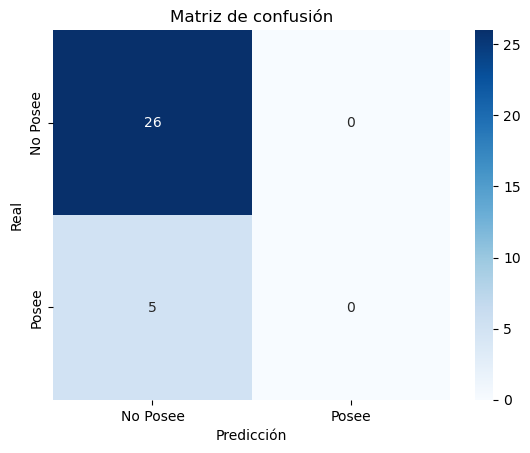

```python
for n in vecinos:
        #Construcción de modelo KNN
    model=KNeighborsRegressor(n_neighbors=120, metric='manhattan')#euclidean,manhattan,minkowski,chebyshev
    #X_train, X_test, y_train, y_test = train_test_split(X, Y, test_size = 0.1, random_state = 42)
    X_train, X_test, y_train, y_test = train_test_split(X_Transformado, Y, test_size = 0.2)
    print(X_train.shape,y_train.shape)
    print(X_test.shape,y_test.shape)
    history = model.fit(X_train, y_train)
    print('Modelo Optimizado entrenado')
    guardarModelo(model,'modeloOptimizadoKNN')
    print('Modelo Optimizado Guardado')
    print(n)

 ##------------------------------------------------------------------------------
    #Predicciones
    y_pred = model.predict(X_test)
    y_pred = y_pred.flatten()
    y_pred = transformarPrediccion(y_pred)
    dataframeFinal=pd.DataFrame({'real':y_test, 'predicción': y_pred})
    np.set_printoptions(formatter={'float': lambda X: "{0:0.0f}".format(X)})
    dataframeFinal.head()


#---------------------------------------------------------------------------------------------------
    #medidas
    MAE=metrics.mean_absolute_error(y_test, y_pred)
    MSE=metrics.mean_squared_error(y_test, y_pred)
    RMSE=np.sqrt(metrics.mean_squared_error(y_test, y_pred))

    MAE=str(round(MAE, 4))
    MSE=str(round(MSE, 4))
    RMSE=str(round(RMSE, 4))


    print('Mean Absolute Error (MAE):', MAE)
    print('Mean Squared Error (MSE):', MSE)
    print('Root Mean Squared Error (RMSE):', RMSE)

    pacientesRMSE.append(RMSE)

    y_testBinario = (y_test >= 0.5).astype("int32")
    y_predBinario = (y_pred >= 0.5).astype("int32")

    #y_pred=y_pred.flatten()# de 2D a 1D

    accuracyModeloBase=str(accuracy_score(y_testBinario, y_predBinario))
    print('Accuracy: ' + accuracyModeloBase)

    precision=precision_score(y_testBinario, y_predBinario)
    precision=str(round(precision, 4))
    print('Precision: ',precision)

    recall=recall_score(y_testBinario, y_predBinario)
    recall=str(round(recall, 4))
    print('Recall: ',recall)

    f1=f1_score(y_testBinario, y_predBinario)
    f1=str(round(f1, 4))
    print('F1:',f1)

    print('Matriz de confusión:')
    tn, fp, fn, tp = confusion_matrix(y_testBinario, y_predBinario).ravel()
    print('Verdaderos negativos: ',tn,' Falsos positivos: ',fp,' Falsos negativos: ',fn,' Verdaderos positivos: ',tp)

    from sklearn.metrics import confusion_matrix
    labels = ['No Posee', 'Posee']
    cm = confusion_matrix(y_testBinario, y_predBinario)
    ax= plt.subplot()
    sns.heatmap(cm, annot=True, ax = ax, cmap='Blues', fmt='g'); #annot=True to annotate cells
    ax.set_xlabel('Predicción');ax.set_ylabel('Real');
    ax.set_title('Matriz de confusión');
    ax.xaxis.set_ticklabels(labels); ax.yaxis.set_ticklabels(labels);



    print("Proceso terminado")
```

[figure not shown]

## 5. Predicción con nuevos samples

```python
def cargarPipeline(nombreArchivo):
    with open(nombreArchivo+'.pickle', 'rb') as handle:
        pipeline = pickle.load(handle)
    return pipeline

def cargarModelo(nombreArchivo):
    with open(nombreArchivo+'.pickle', 'rb') as handle:
        pipeline = pickle.load(handle)
    return pipeline

def obtenerResultadosyCertezas(lista):
    predicciones=lista
    marcas=[]
    certezas=[]
    nuevomax=1
    nuevomin=0
    marca=-1
    certeza=-1
    for i in range(len(lista)):
        prediccion=lista[i]
        if (prediccion < 0.5):
            marca = 'Muere'
            maxa=0.5
            mina=0
            certeza=1-((prediccion-mina)/(maxa-mina)*(nuevomax-nuevomin)+nuevomin)
            certeza=str(int((certeza)*100))+'%'
        elif (prediccion >= 0.5):
            marca = 'Vive'
            maxa=1
            mina=0.5
            certeza=(prediccion-mina)/(maxa-mina)*(nuevomax-nuevomin)+nuevomin
            certeza=str(int((certeza)*100))+'%'
        marcas.append(marca)
        certezas.append(certeza)
    return prediccion, marcas, certezas

def predecirNuevoPaciente(SEXO='1', ESTEROIDES='1', ANTIVIRALES='2', FATIGA='1', MALESTAR='2', ANOREXIA='2', HIGADOGRANDE='1', HIGADOFIRME=2,  BAZOPALPABLE='2', ARAÑAS='2', ASCITIS='2', VARICES='2', HISTOLOGIA='1',  EDAD='50', FOSFATASAALCALINA='135', SGOT='42', PRUEBADETIEMPO='1'):
    cnames=['SEXO','ESTEROIDES','ANTIVIRALES','FATIGA','MALESTAR','ANOREXIA','HIGADOGRANDE','HIGADOFIRME','BAZOPALPABLE','ARAÑAS','ASCITIS','VARICES','HISTOLOGIA','EDAD','FOSFATASAALCALINA','SGOT','PRUEBADETIEMPO']
    Xnew=[SEXO, ESTEROIDES, ANTIVIRALES, FATIGA, MALESTAR, ANOREXIA, HIGADOGRANDE, HIGADOFIRME, BAZOPALPABLE, ARAÑAS, ASCITIS, VARICES, HISTOLOGIA,  EDAD, FOSFATASAALCALINA, SGOT, PRUEBADETIEMPO]
    Xnew_Dataframe = pd.DataFrame(data=[Xnew],columns=cnames)
    pipe=cargarPipeline("pipePreprocesadores")
    Xnew_Transformado=pipe.transform(Xnew_Dataframe)
    modelo=cargarModelo("modeloOptimizadoKNN")
    y_pred=modelo.predict(Xnew_Transformado)
    predicciones, marcas, certezas= obtenerResultadosyCertezas(y_pred)
    dataframeFinal=pd.DataFrame({'Predicción':predicciones, 'Resultado':marcas, 'Certeza': certezas})
    np.set_printoptions(formatter={'float': lambda X: "{0:0.0f}".format(X)})
    return dataframeFinal
```

```python
dataframeFinal=predecirNuevoPaciente()
dataframeFinal.head()
```

|  | Predicción | Resultado | Certeza |
| --- | --- | --- | --- |
| 0 | 0.216667 | Muere | 56% |

# 3. Desarrollo y Evaluación de modelo Naive Bayes

```python
import pandas as pd
from sklearn.naive_bayes import GaussianNB
from sklearn.model_selection import train_test_split


# Dividimos los datos en conjuntos de entrenamiento y prueba
X_train, X_test, y_train, y_test = train_test_split(X_Transformado, Y, test_size=0.2)

# Creamos y entrenamos un modelo de regresión logística
modelo = GaussianNB()
modelo.fit(X_train, y_train)

# Evaluamos el rendimiento del modelo en el conjunto de prueba
puntuacion = modelo.score(X_test, y_test)
print(f'Puntuación del modelo: {puntuacion}')
```

```
Puntuación del modelo: 0.4838709677419355
```

```python
#Predicciones
y_pred = model.predict(X_test)
y_pred = y_pred.flatten()
y_pred = transformarPrediccion(y_pred)
dataframeFinal=pd.DataFrame({'real':y_test, 'predicción': y_pred})
np.set_printoptions(formatter={'float': lambda X: "{0:0.0f}".format(X)})
dataframeFinal.head(10)
```

|  | real | predicción |
| --- | --- | --- |
| 28 | 0 | 0.200000 |
| 75 | 0 | 0.216667 |
| 68 | 0 | 0.216667 |
| 62 | 0 | 0.225000 |
| 84 | 0 | 0.208333 |
| 17 | 0 | 0.208333 |
| 21 | 0 | 0.225000 |
| 45 | 0 | 0.208333 |
| 127 | 1 | 0.225000 |
| 66 | 0 | 0.216667 |

```
Mean Absolute Error (MAE): 0.3599
Mean Squared Error (MSE): 0.1907
Root Mean Squared Error (RMSE): 0.4367
Accuracy: 0.7419354838709677
Precision:  0.0
Recall:  0.0
F1: 0.0
Matriz de confusión:
Verdaderos negativos:  23  Falsos positivos:  0  Falsos negativos:  8  Verdaderos positivos:  0
```

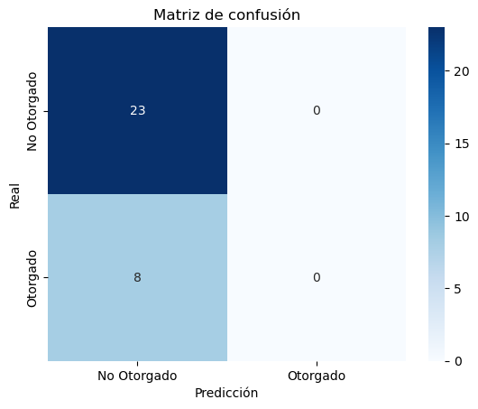

```python
MAE=metrics.mean_absolute_error(y_test, y_pred)
MSE=metrics.mean_squared_error(y_test, y_pred)
RMSE=np.sqrt(metrics.mean_squared_error(y_test, y_pred))

MAE=str(round(MAE, 4))
MSE=str(round(MSE, 4))
RMSE=str(round(RMSE, 4))

print('Mean Absolute Error (MAE):', MAE)
print('Mean Squared Error (MSE):', MSE)
print('Root Mean Squared Error (RMSE):', RMSE)

y_testBinario = (y_test >= 0.5).astype("int32")
y_predBinario = (y_pred >= 0.5).astype("int32")

#y_pred=y_pred.flatten()# de 2D a 1D

accuracyModeloBase=str(accuracy_score(y_testBinario, y_predBinario))
print('Accuracy: ' + accuracyModeloBase)

precision=precision_score(y_testBinario, y_predBinario)
precision=str(round(precision, 4))
print('Precision: ',precision)

recall=recall_score(y_testBinario, y_predBinario)
recall=str(round(recall, 4))
print('Recall: ',recall)

f1=f1_score(y_testBinario, y_predBinario)
f1=str(round(f1, 4))
print('F1:',f1)

print('Matriz de confusión:')
tn, fp, fn, tp = confusion_matrix(y_testBinario, y_predBinario).ravel()
print('Verdaderos negativos: ',tn,' Falsos positivos: ',fp,' Falsos negativos: ',fn,' Verdaderos positivos: ',tp)

from sklearn.metrics import confusion_matrix
labels = ['No Otorgado', 'Otorgado']
cm = confusion_matrix(y_testBinario, y_predBinario)
ax= plt.subplot()
sns.heatmap(cm, annot=True, ax = ax, cmap='Blues', fmt='g'); #annot=True to annotate cells
ax.set_xlabel('Predicción');ax.set_ylabel('Real');
ax.set_title('Matriz de confusión');
ax.xaxis.set_ticklabels(labels); ax.yaxis.set_ticklabels(labels);
```

```python
def cargarPipeline(nombreArchivo):
    with open(nombreArchivo+'.pickle', 'rb') as handle:
        pipeline = pickle.load(handle)
    return pipeline

def cargarModelo(nombreArchivo):
    with open(nombreArchivo+'.pickle', 'rb') as handle:
        pipeline = pickle.load(handle)
    return pipeline

def obtenerResultadosyCertezas(lista):
    predicciones=lista
    marcas=[]
    certezas=[]
    nuevomax=1
    nuevomin=0
    marca=-1
    certeza=-1
    for i in range(len(lista)):
        prediccion=lista[i]
        if (prediccion < 0.5):
            marca = 'Muere'
            maxa=0.5
            mina=0
            certeza=1-((prediccion-mina)/(maxa-mina)*(nuevomax-nuevomin)+nuevomin)
            certeza=str(int((certeza)*100))+'%'
        elif (prediccion >= 0.5):
            marca = 'Vive'
            maxa=1
            mina=0.5
            certeza=(prediccion-mina)/(maxa-mina)*(nuevomax-nuevomin)+nuevomin
            certeza=str(int((certeza)*100))+'%'
        marcas.append(marca)
        certezas.append(certeza)
    return prediccion, marcas, certezas

def predecirNuevoPaciente(SEXO='1', ESTEROIDES='1', ANTIVIRALES='2', FATIGA='1', MALESTAR='2', ANOREXIA='2', HIGADOGRANDE='1', HIGADOFIRME=2,  BAZOPALPABLE='2', ARAÑAS='2', ASCITIS='2', VARICES='2', HISTOLOGIA='1',  EDAD='50', FOSFATASAALCALINA='135', SGOT='42', PRUEBADETIEMPO='1'):
    cnames=['SEXO','ESTEROIDES','ANTIVIRALES','FATIGA','MALESTAR','ANOREXIA','HIGADOGRANDE','HIGADOFIRME','BAZOPALPABLE','ARAÑAS','ASCITIS','VARICES','HISTOLOGIA','EDAD','FOSFATASAALCALINA','SGOT','PRUEBADETIEMPO']
    Xnew=[SEXO, ESTEROIDES, ANTIVIRALES, FATIGA, MALESTAR, ANOREXIA, HIGADOGRANDE, HIGADOFIRME, BAZOPALPABLE, ARAÑAS, ASCITIS, VARICES, HISTOLOGIA,  EDAD, FOSFATASAALCALINA, SGOT, PRUEBADETIEMPO]
    Xnew_Dataframe = pd.DataFrame(data=[Xnew],columns=cnames)
    pipe=cargarPipeline("pipePreprocesadores")
    Xnew_Transformado=pipe.transform(Xnew_Dataframe)
    modelo=cargarModelo("modeloOptimizadoKNN")
    y_pred=modelo.predict(Xnew_Transformado)
    predicciones, marcas, certezas= obtenerResultadosyCertezas(y_pred)
    dataframeFinal=pd.DataFrame({'Predicción':predicciones, 'Resultado':marcas, 'Certeza': certezas})
    np.set_printoptions(formatter={'float': lambda X: "{0:0.0f}".format(X)})
    return dataframeFinal
```

```python
dataframeFinal=predecirNuevoPaciente()
dataframeFinal.head()
```

|  | Predicción | Resultado | Certeza |
| --- | --- | --- | --- |
| 0 | 0.216667 | Muere | 56% |

```python
#https://archive.ics.uci.edu/ml/datasets/statlog+(german+credit+data)
#sin empleo: A71
dataframeFinal=predecirNuevoPaciente(SEXO='2', ESTEROIDES='1', ANTIVIRALES='2', FATIGA='2', MALESTAR='2', ANOREXIA='2', HIGADOGRANDE='1', HIGADOFIRME=2,  BAZOPALPABLE='2', ARAÑAS='2', ASCITIS='2', VARICES='2', HISTOLOGIA='1', EDAD='30', FOSFATASAALCALINA='85', SGOT='18', PRUEBADETIEMPO='1')
dataframeFinal.head()
```

|  | Predicción | Resultado | Certeza |
| --- | --- | --- | --- |
| 0 | 0.216667 | Muere | 56% |

# 4. COMPARACIÓN DE MODELOS KNN Y NAIVE BAYES

[figure not shown]

# 6. CONCLUSIONES Y REFERENCIAS

[1] Aprende con Alf. (2021). La librería Pandas. 11/11/2021, de Aprende con Alf Sitio web:https://aprendeconalf.es/docencia/python/manual/pandas/**

[2] Bishop, C. M. (2006). Pattern recognition and machine learning. springer.

[3] El Naqa, I., & Murphy, M. J. (2015). What is machine learning?. In machine learning in radiation oncology (pp. 3-11). Springer, Cham.

[4] Duda, R. O., Hart, P. E., & Stork, D. G. (2012). Pattern classification. John Wiley & Sons.

[5] P. Joshi. (2017). Artificial intelligence with python. Packt Publishing Ltd.

[6] Brownlee. J. (2019, Agosto 12). A Tour of Machine Learning Algorithms [Machine Learning Mastery]. Recuperado de https://machinelearningmastery.com/a-tour-of-machine-learning-algorithms/

[7] Dua, D. and Graff, C. (2019). UCI Machine Learning Repository [http://archive.ics.uci.edu/ml]. Irvine, CA: University of California, School of Information and Computer Science.

[8] Müller, A. (2020). More on Pipelines. [Applied Machine Learning with Python]. Recuperado de https://amueller.github.io/aml/01-ml-workflow/12-pipelines-gridsearch.html

[9] Martinez, J. (2020). Precision, Recall, F1, Accuracy en clasificación [IArtificial.net]. Recuperado de https://www.iartificial.net/precision-recall-f1-accuracy-en-clasificacion/

[10] Scholkopf, B., & Smola, A. J. (2018). Learning with kernels: support vector machines, regularization, optimization, and beyond. Adaptive Computation and Machine Learning series.

[11] Online recuperado el 15 de mayo del 2023. https://scikit-learn.org/stable/modules/naive_bayes.html